# Reproducible Research: Peer Assessment 1

## Dataset:

[Activity monitoring data](https://d396qusza40orc.cloudfront.net/repdata%2Fdata%2Factivity.zip) [52K] The variables included in this dataset are:

-steps: Number of steps taking in a 5-minute interval (missing values are coded as 𝙽𝙰) -date: The date on which the measurement was taken in YYYY-MM-DD format -interval: Identifier for the 5-minute interval in which measurement was taken

The dataset is stored in a comma-separated-value (CSV) file and there are a total of 17,568 observations in this dataset.

## Loading and preprocessing the data

```r
if(!file.exists("activity.csv")){unzip(zipfile="activity.zip")}

data <- read.csv("activity.csv")
#Date Transform
#data$date <- as.Date(data$date, format = "%Y%m%d")
#class(data$date)=="Date"
```

## What is mean total number of steps taken per day?

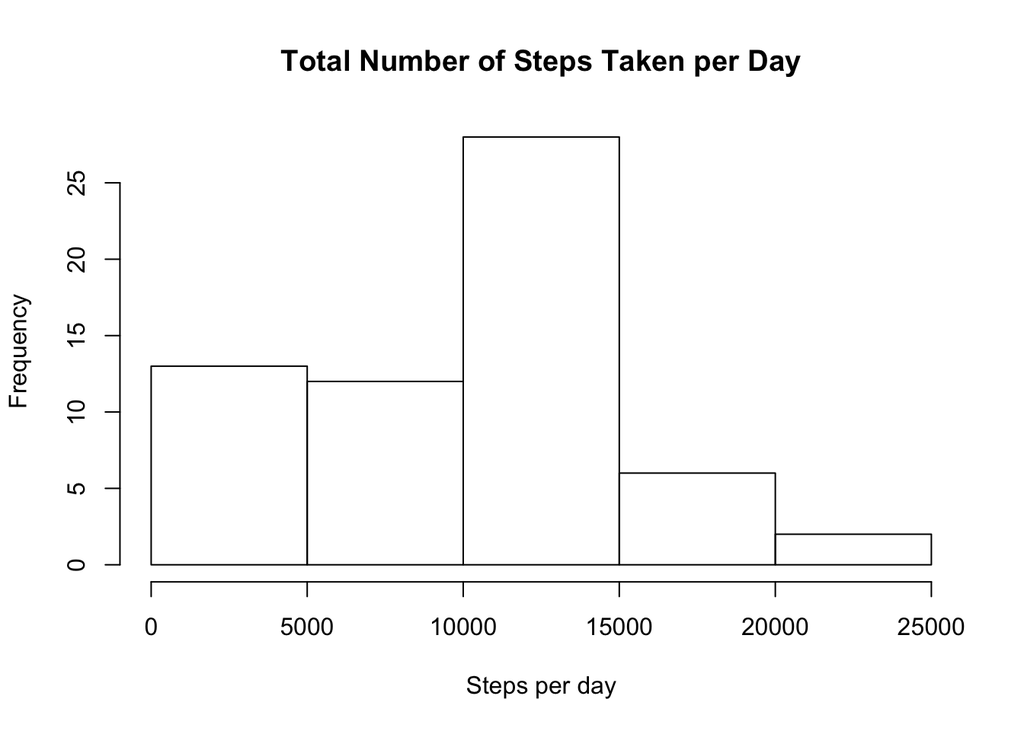

```r
library(ggplot2)
steps <- tapply(data$steps, data$date, FUN=sum, na.rm=TRUE)
###Histogram of total number of steps taken per day
hist(steps, main = paste("Total Number of Steps Taken per Day"), xlab= "Steps per day" )
```

```r
###Mean Steps
mean1 <- mean(steps, na.rm=TRUE)
###median steps
median1 <- median(steps, na.rm = TRUE)
```

Graphed and seen abovve the mean steps taken each day is 9354.2295082 and the median is 10395.

## What is the average daily activity pattern?

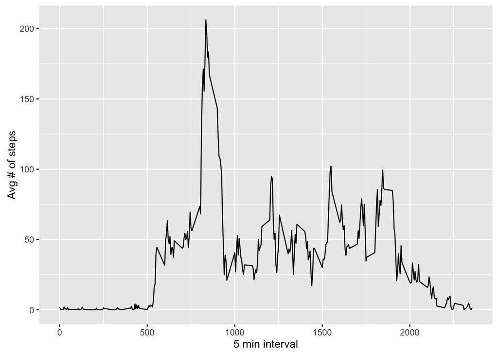

```r
library(ggplot2)
avg <- aggregate(x=list(steps=data$steps), by=list(interval=data$interval),
                      FUN=mean, na.rm=TRUE)
ggplot(data=avg, aes(x=interval, y=steps)) +
    geom_line() +
    xlab("5 min interval") +
    ylab("Avg # of steps")
```

```r
##calculate which interval has max steps
maxstep <- avg[which.max(avg$steps),]
```

## Imputing missing values

```r
missing <- is.na(data$steps)
# How many missing
num.missing <- sum(missing)
```

To adjust for missing values, we use mean/median for that 5-minute interval

```r
# fuction for replacing missing values with mean value of its 5-minute interval
fill.value <- function(steps, interval) {
    filled <- NA
    if (!is.na(steps))
        filled <- c(steps)
    else
        filled <- (avg[avg$interval==interval, "steps"])
    return(filled)
}
#create a new dataset with filled data using the filling fuction
data.filled <- data
data.filled$steps <- mapply(fill.value, data.filled$steps, data.filled$interval)
```

Now, using the filled data set, here is a histogram of the total number of steps taken each day with the mean and median total number of steps.

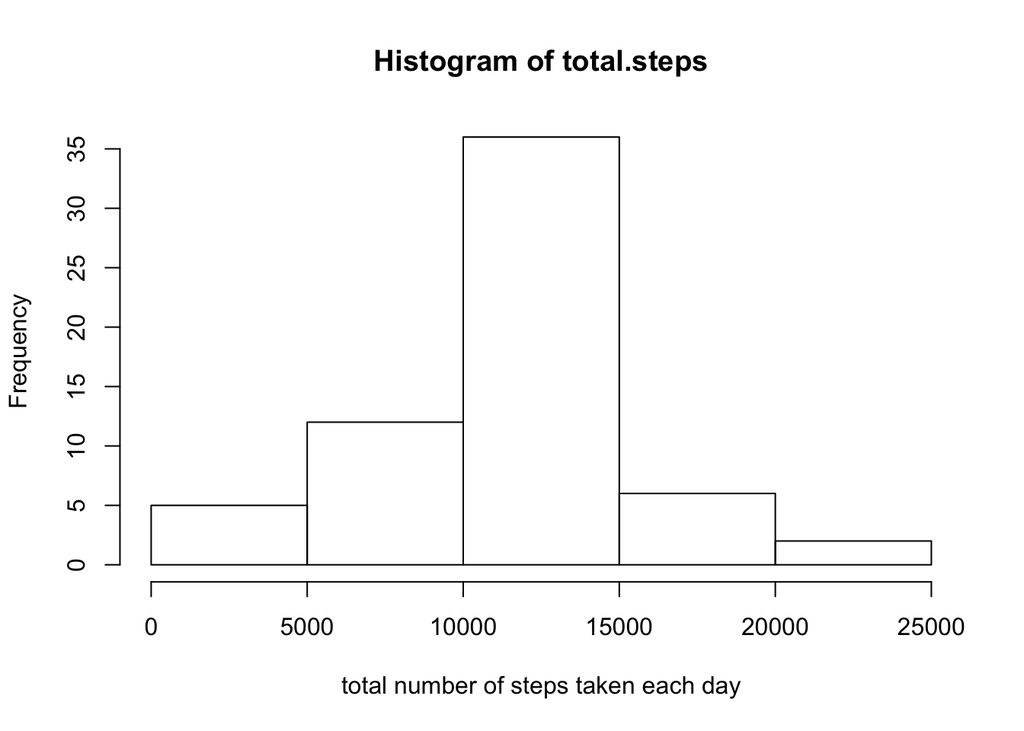

```r
total.steps <- tapply(data.filled$steps, data.filled$date, FUN=sum)
hist(total.steps, xlab="total number of steps taken each day")
```

```r
###Mean Steps
mean2 <- mean(total.steps, na.rm=TRUE)
###median steps
median2 <- median(total.steps, na.rm = TRUE)
```

Notice the impact of imputing missing data on the estimates of the total daily number of steps:

## Are there differences in activity patterns between weekdays and weekends?

```r
weekday.or.weekend <- function(date) {
    day <- weekdays(date)
    if (day %in% c("Monday", "Tuesday", "Wednesday", "Thursday", "Friday"))
        return("weekday")
    else if (day %in% c("Saturday", "Sunday"))
        return("weekend")
    else
        stop("invalid date")
}
data.filled$date <- as.Date(data.filled$date)
data.filled$day <- sapply(data.filled$date, FUN=weekday.or.weekend)
```

Now, let’s make a panel plot containing plots of average number of steps taken on weekdays and weekends.

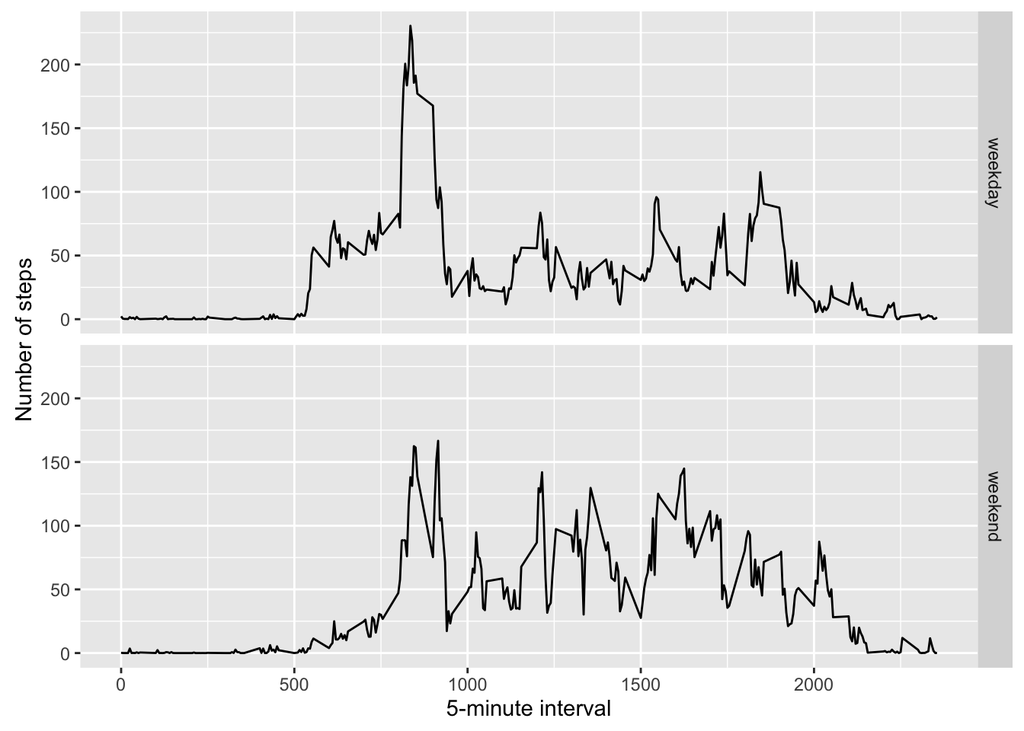

```r
library(ggplot2)
# Aggragate step means by interval and weekday vs weekend for plotting
means.data.filled <- aggregate(steps ~ interval + day, data = data.filled, FUN = mean.default )

ggplot(means.data.filled, aes(interval, steps)) + geom_line() + facet_grid(day ~ .) +
    xlab("5-minute interval") + ylab("Number of steps")
```